# Lab 3

Eric Gleiter; Brandon Xicon

2/19/2020

*Note: All package checks and installations code is hidden on the html please see the Rmd file for data cleaning and package loading*

**Question 1)**

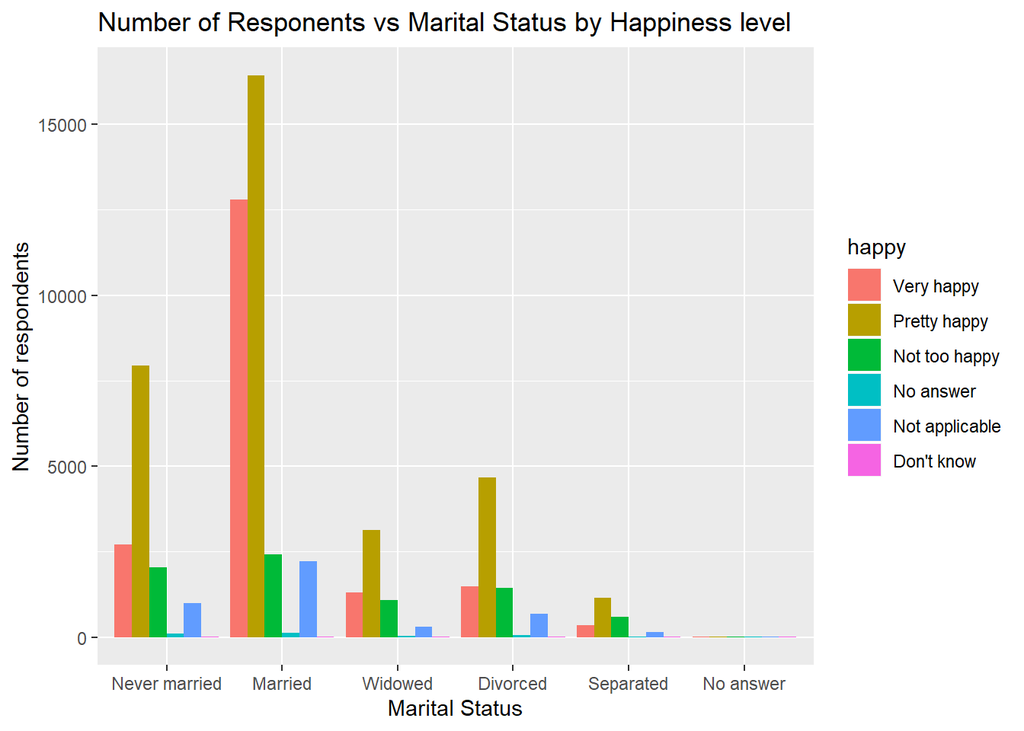

```r
ggplot(data = dat1, aes(x=married, fill=happy)) + geom_bar(position = 'Dodge') +xlab("Marital Status") + ylab("Number of respondents") + labs(title="Number of Responents vs Marital Status by Happiness level")
```

Looking at the bar graph we can see a few common patterns in that the most common level of happiness is just pretty happy. Beyond that the ratio of very happy to everything else is higher for married respondents than for the not married respondents and the ratio of not to hapy rises for those who were married but arent anymore. This suggests that married people are happier and that having married and then separating or divorcing leads to an unhappy life.

**Question 2)**

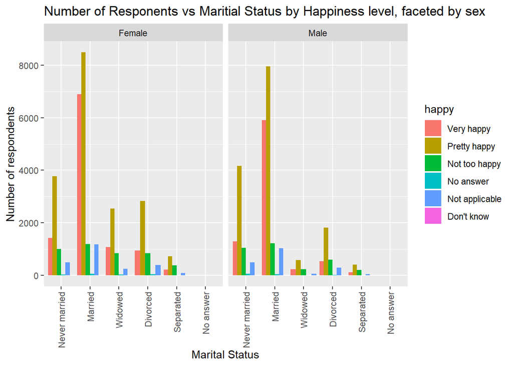

```r
ggplot(data = dat1, aes(x=married, fill=happy)) + geom_bar(position = 'Dodge') + theme(axis.text.x=element_text(angle=90,hjust=1,vjust=0.5)) + facet_wrap(vars(sex)) +xlab("Marital Status") + ylab("Number of respondents") + labs(title="Number of Responents vs Maritial Status by Happiness level, faceted by sex")
```

Comparing the two the only real diiference is that across the board men are more likely to respond as “not to happy” and not “very happy” so I would say that no the sex of the respondent does not affect the relationships found in question 1.

**Question 3)** How does the happiness of a respondent relate to the political party affiliation?

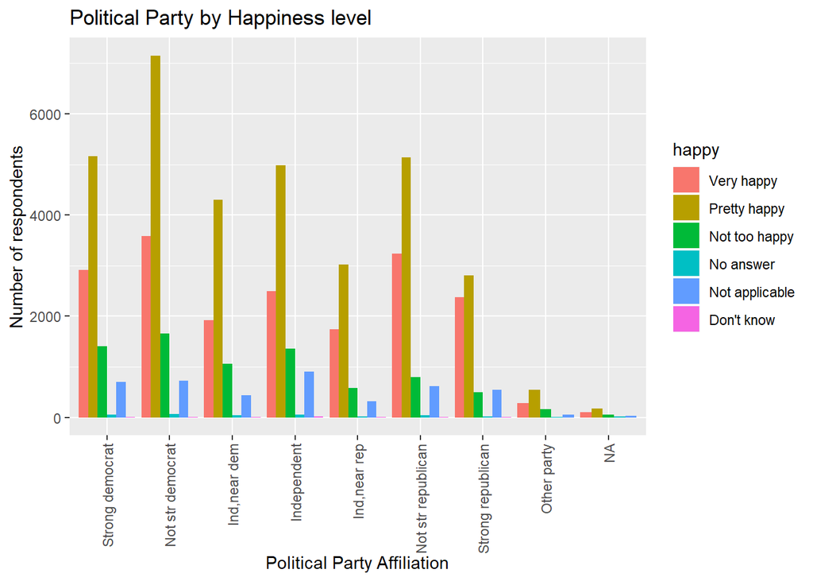

```r
dat1$political <- factor(dat1$`Political party affiliation`, levels= c('Strong democrat', 'Not str democrat','Ind,near dem','Independent','Ind,near rep','Not str republican','Strong republican', 'Other party'))
ggplot(data = dat1, aes(x=political, fill=happy)) + geom_bar(position = 'Dodge') +xlab("Political Party Affiliation") + ylab("Number of respondents") + labs(title="Political Party by Happiness level")+theme(axis.text.x=element_text(angle=90,hjust=1,vjust=0.5))
```

Based on the graph it shows that the happiness does not really differ between party affiliation however it is unusual that not str democrats had a large number of people that were “Pretty happy” compared to the other parties and in general no matter what group each party was pretty happy then next occured was very happy and the least occurence was not too happy.

**Question idea 1 of 4)** Does Age affect the political affiliation of a person and how does sex affect this relationship?

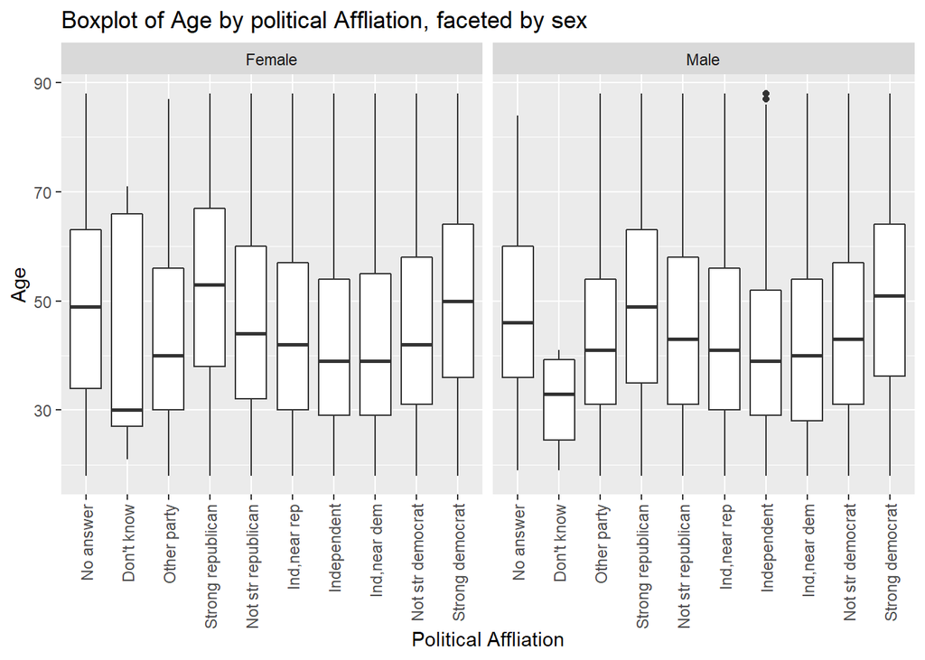

```r
ggplot(data = dat1, aes(x=politicalParty, y=age)) + geom_boxplot() + theme(axis.text.x=element_text(angle=90,hjust=1,vjust=0.5)) + facet_wrap(vars(sex)) +xlab("Political Affliation") + ylab("Age") + labs(title="Boxplot of Age by political Affliation, faceted by sex")
```

Looking at the side by side box plots we can see a fairly obvious trend. The younger someone is the more likly they are to be independent. Additionally it is interesting to not that the party itself doesnt matter with regards to age. The only thing that seems to happen is that as people get older they are more likely to indentify as strongly one way or the other. Looking at the differences caused by sex the only real difference we can see is that older men are more likly to be democrate where as older females are more likly to be strong republicans.

**Question idea 2 of 4)** How does age impact happiness, and how does Health affect this?

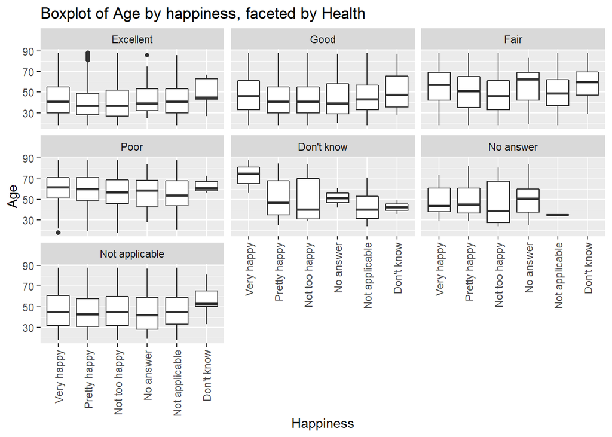

```r
ggplot(data = dat1, aes(x=happy, y=age)) + geom_boxplot() + theme(axis.text.x=element_text(angle=90,hjust=1,vjust=0.5)) + facet_wrap(vars(health)) +xlab("Happiness") + ylab("Age") + labs(title="Boxplot of Age by happiness, faceted by Health")
```

The relationship between and age seems to not actually matter the median age of all happiness levels are about the same there isnt one group that is happier than another. It interesting to note that as median age increases the health condition decreases. The most interesting thing is that when people respond that they don’t know what their health is like then there is a relationship between age and happiness. Older peole tend to be happier when they dont know their health condition. It seems to be that if you want to stay happy when you get old stop worrying about your health.

…

**Question idea 3 of 4)** How does ones education or degree and labor status affect the persons overall happiness?

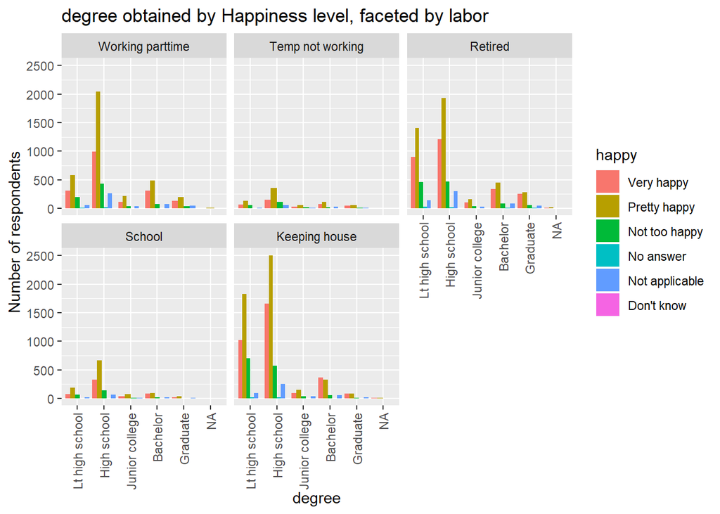

```r
dat1$labor <- factor(dat1$`Labor force status`, levels= c( 'Working parttime','Temp not working','unempl, laid off','Retired','School','Keeping house'))
dat1$degree <- factor(dat1$`Rs highest degree`, levels= c('Lt high school', 'High school','Junior college','Bachelor','Graduate','Don\t know'))
ggplot(data = subset(dat1,!is.na(labor)), aes(x=degree, fill=happy)) + geom_bar(position = 'Dodge') + theme(axis.text.x=element_text(angle=90,hjust=1,vjust=0.5)) + facet_wrap(vars(labor)) +xlab("degree") + ylab("Number of respondents") + labs(title="degree obtained by Happiness level, faceted by labor")
```

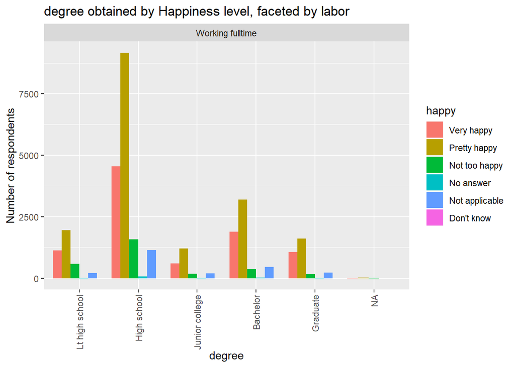

```r
dat1$labor <- factor(dat1$`Labor force status`, levels= c('Working fulltime'))
ggplot(data = subset(dat1,!is.na(labor)), aes(x=degree, fill=happy)) + geom_bar(position = 'Dodge') + theme(axis.text.x=element_text(angle=90,hjust=1,vjust=0.5)) + facet_wrap(vars(labor)) +xlab("degree") + ylab("Number of respondents") + labs(title="degree obtained by Happiness level, faceted by labor")
```

**Question idea 4 of 4)** How does the number of kids a person has as well as their age impact their happiness?

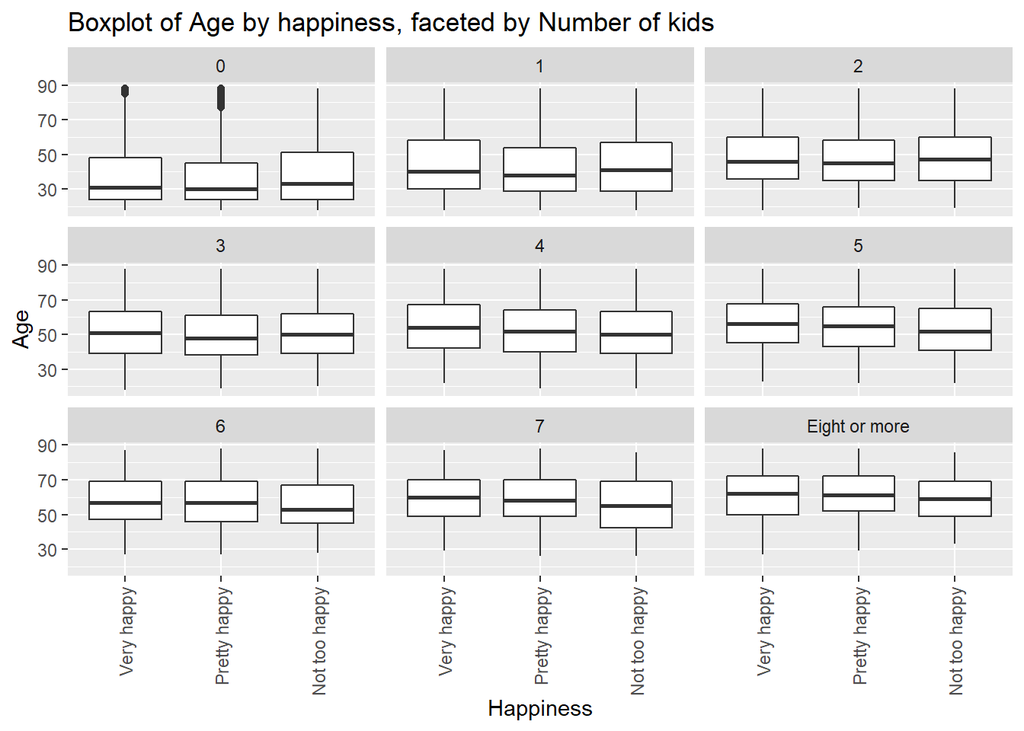

```r
dat1$child <- factor(dat1$`Number of children`, levels= c('0', '1','2','3','4','5','6','7','Eight or more'))
dat1$happy <- factor(dat1$`General happiness`, levels = c('Very happy','Pretty happy','Not too happy'))
ggplot(data = subset(subset(dat1,!is.na(happy)),!is.na(child)), aes(x=happy, y=age)) + geom_boxplot() + theme(axis.text.x=element_text(angle=90,hjust=1,vjust=0.5)) + facet_wrap(vars(child)) +xlab("Happiness") + ylab("Age") + labs(title="Boxplot of Age by happiness, faceted by Number of kids")
```

Looking at the boxplots we see that the median of age for not too happy is slightly larger if the resondent has 0-2 kids which then levels out and becomes slightly lower than the median of the other 2 happiness factors from 3-8+ kids. This is interesting as I interpret it as those that don’t have many kids and are not too happy are generally older, and if they have many kids then there is no real difference between happiness and age.